# Estudio estadístico sobre teleorientación psicológica dirigido a usuarios de Óyeme mayores de 18 años que requieran atención para la salud mental debido a la pandemia atravesada

##### Intervalo de confianza para la hipótesis 2

Intervalo de confianza: [1.6, 5>

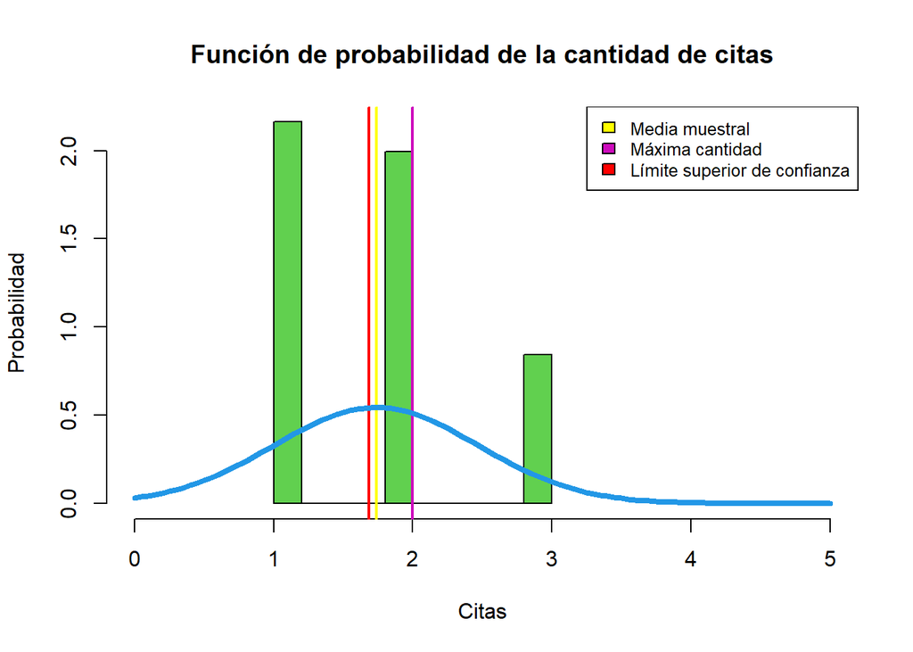

#### Edad

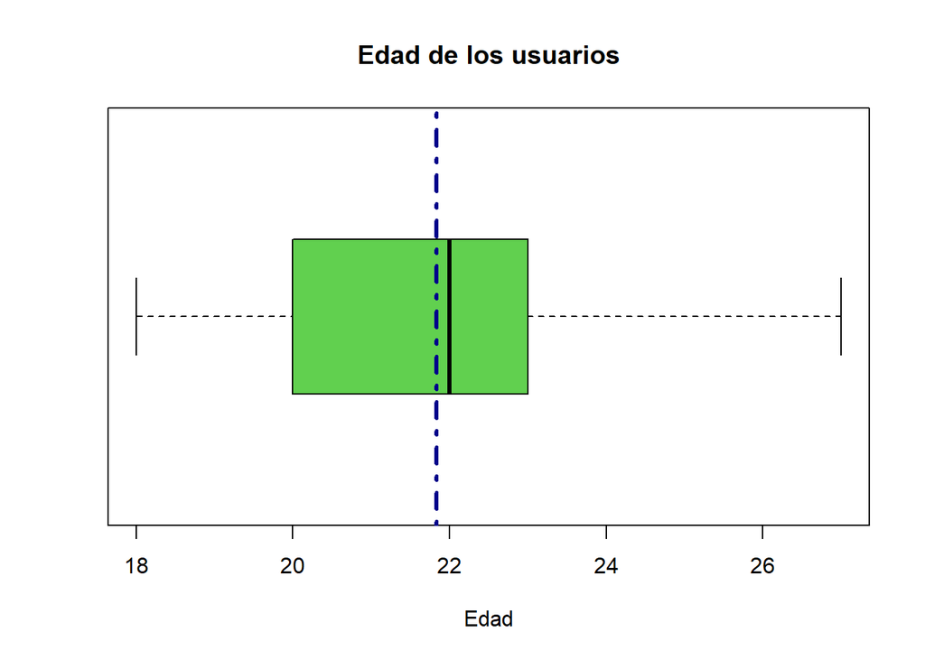

##### HIPÓTESIS III

Ho = La edad que tiene mayor cantidad de horas de estudio son en promedio **mayores o iguales** a 26 años

$H_{0}:µ >= 26$

H1 = La edad que tiene mayor cantidad de horas de estudio son en promedio **menores** a 26 años

$H_{1}:µ < 26$

Se eligió un nivel de confianza de 80% debido a que los datos no están muy dispersos (rango: 18, 27), por lo que se prioriza una mayor precisión sobre una mayor confianza. Al usar dicho nivel de confianza el error será ±0.15 y el tamaño de muestra empleada es 151.

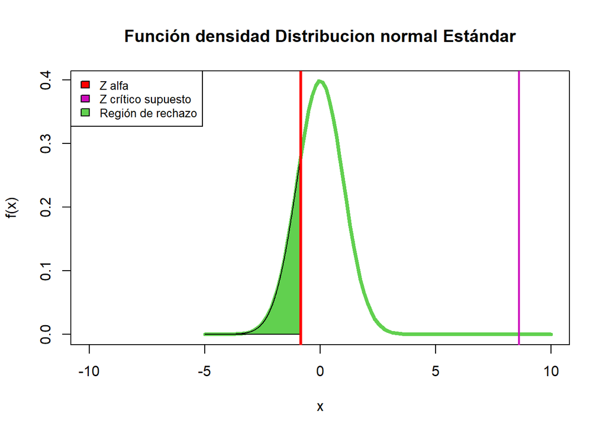

##### Intervalo de confianza para la hipótesis 3

Intervalo de confianza: [21.5, 30>

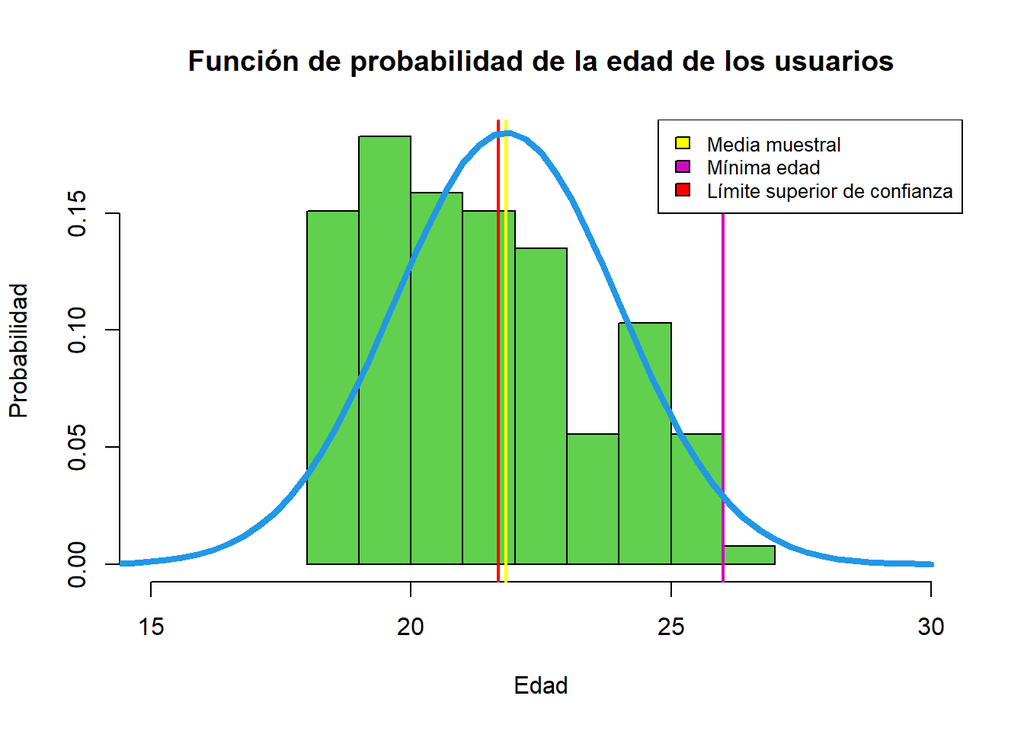